# GERMAN CREDIT SCORE

Daniel Obare

10/5/2019

```r
require(flexdashboard)
require(knitr)
require(ggplot2)
require(magrittr)
require(kableExtra)
require(dplyr)
require(knitr)
require(caret)
require(lattice)
require(gplots)
require(ROCR)
require(ggthemes)
require(broom)
require(grid)
require(gridExtra)
require(scales)
require(tidyr)
require(pROC)
require(data.table)
theme_set(theme_economist())
load(file = "german.Rdata")
```

**Goal** The aim is to find a suitable credit score algorithm.

**Practical suggestion.** Building high performance mdels requires skill, ability to conceptualize and understand data relationships. Some theory, it is helpful to be versed in the appropriate literature, brainstorm relationships that hould exist in data and test them out.

## General view of the data to model

```r
german %>% kable() %>%
  kable_styling() %>%
  scroll_box(width = "100%", height = "200px")
```

| Creditability | Account.Balance | Duration.of.Credit..month. | Payment.Status.of.Previous.Credit | Purpose | Credit.Amount | Value.Savings.Stocks | Length.of.current.employment | Instalment.per.cent | Sex…Marital.Status | Guarantors | Duration.in.Current.address | Most.valuable.available.asset | Age..years. | Concurrent.Credits | Type.of.apartment | No.of.Credits.at.this.Bank | Occupation | No.of.dependents | Telephone | Foreign.Worker |
| --- | --- | --- | --- | --- | --- | --- | --- | --- | --- | --- | --- | --- | --- | --- | --- | --- | --- | --- | --- | --- |
| non-defaulter | verylow | 18 | 4 | 2 | 1049 | very-high | 2 | 4 | female-married | 1 | 4 | appartment | 21 | 3 | own | 1 | 3 | 1 | 1 | 1 |
| non-defaulter | verylow | 9 | 4 | 0 | 2799 | very-high | 3 | 2 | male-single | 1 | 2 | land | 36 | 3 | own | 2 | 3 | 2 | 1 | 1 |
| non-defaulter | low | 12 | 2 | 9 | 841 | high | 4 | 2 | female-married | 1 | 4 | land | 23 | 3 | own | 1 | 2 | 1 | 1 | 1 |
| non-defaulter | verylow | 12 | 4 | 0 | 2122 | very-high | 3 | 3 | male-single | 1 | 2 | land | 39 | 3 | own | 2 | 2 | 2 | 1 | 2 |
| non-defaulter | verylow | 12 | 4 | 0 | 2171 | very-high | 3 | 4 | male-single | 1 | 4 | appartment | 38 | 1 | rental | 2 | 2 | 1 | 1 | 2 |
| non-defaulter | verylow | 10 | 4 | 0 | 2241 | very-high | 2 | 1 | male-single | 1 | 3 | land | 48 | 3 | own | 2 | 2 | 2 | 1 | 2 |
| non-defaulter | verylow | 8 | 4 | 0 | 3398 | very-high | 4 | 1 | male-single | 1 | 4 | land | 39 | 3 | rental | 2 | 2 | 1 | 1 | 2 |
| non-defaulter | verylow | 6 | 4 | 0 | 1361 | very-high | 2 | 2 | male-single | 1 | 4 | land | 40 | 3 | rental | 1 | 2 | 2 | 1 | 2 |
| non-defaulter | veryhigh | 18 | 4 | 3 | 1098 | very-high | 1 | 4 | female-married | 1 | 4 | bussines | 65 | 3 | rental | 2 | 1 | 1 | 1 | 1 |
| non-defaulter | low | 24 | 2 | 3 | 3758 | medium | 1 | 1 | female-married | 1 | 4 | car | 23 | 3 | own | 1 | 1 | 1 | 1 | 1 |
| non-defaulter | verylow | 11 | 4 | 0 | 3905 | very-high | 3 | 2 | male-single | 1 | 2 | land | 36 | 3 | own | 2 | 3 | 2 | 1 | 1 |
| non-defaulter | verylow | 30 | 4 | 1 | 6187 | high | 4 | 1 | male-married | 1 | 4 | bussines | 24 | 3 | own | 2 | 3 | 1 | 1 | 1 |
| non-defaulter | verylow | 6 | 4 | 3 | 1957 | very-high | 4 | 1 | female-married | 1 | 4 | bussines | 31 | 3 | rental | 1 | 3 | 1 | 1 | 1 |
| non-defaulter | low | 48 | 3 | 10 | 7582 | high | 1 | 2 | male-single | 1 | 4 | car | 31 | 3 | rental | 1 | 4 | 1 | 2 | 1 |
| non-defaulter | verylow | 18 | 2 | 3 | 1936 | very-low | 4 | 2 | male-married | 1 | 4 | bussines | 23 | 3 | own | 2 | 2 | 1 | 1 | 1 |
| non-defaulter | verylow | 6 | 2 | 3 | 2647 | medium | 3 | 2 | male-single | 1 | 3 | land | 44 | 3 | own | 1 | 3 | 2 | 1 | 1 |
| non-defaulter | verylow | 11 | 4 | 0 | 3939 | very-high | 3 | 1 | male-single | 1 | 2 | land | 40 | 3 | rental | 2 | 2 | 2 | 1 | 1 |
| non-defaulter | low | 18 | 2 | 3 | 3213 | medium | 2 | 1 | male-married | 1 | 3 | land | 25 | 3 | own | 1 | 3 | 1 | 1 | 1 |
| non-defaulter | low | 36 | 4 | 3 | 2337 | very-high | 5 | 4 | male-single | 1 | 4 | land | 36 | 3 | rental | 1 | 3 | 1 | 1 | 1 |
| non-defaulter | veryhigh | 11 | 4 | 0 | 7228 | very-high | 3 | 1 | male-single | 1 | 4 | appartment | 39 | 3 | rental | 2 | 2 | 1 | 1 | 1 |
| non-defaulter | verylow | 6 | 4 | 0 | 3676 | very-high | 3 | 1 | male-single | 1 | 3 | land | 37 | 3 | own | 3 | 3 | 2 | 1 | 1 |
| non-defaulter | low | 12 | 4 | 0 | 3124 | very-high | 2 | 1 | male-single | 1 | 3 | land | 49 | 1 | rental | 2 | 2 | 2 | 1 | 1 |
| defaulter | low | 36 | 2 | 5 | 2384 | very-high | 2 | 4 | male-single | 1 | 1 | car | 33 | 3 | own | 1 | 2 | 1 | 1 | 1 |
| non-defaulter | low | 12 | 4 | 4 | 1424 | very-high | 4 | 4 | male-single | 1 | 3 | appartment | 26 | 3 | rental | 1 | 3 | 1 | 1 | 1 |
| non-defaulter | verylow | 6 | 4 | 0 | 4716 | very-low | 2 | 1 | male-single | 1 | 3 | land | 44 | 3 | rental | 2 | 2 | 2 | 1 | 1 |
| non-defaulter | low | 11 | 3 | 3 | 4771 | very-high | 4 | 2 | male-single | 1 | 4 | appartment | 51 | 3 | rental | 1 | 3 | 1 | 1 | 1 |
| non-defaulter | verylow | 12 | 2 | 2 | 652 | very-high | 5 | 4 | female-married | 1 | 4 | appartment | 24 | 3 | own | 1 | 3 | 1 | 1 | 1 |
| non-defaulter | low | 9 | 4 | 3 | 1154 | very-high | 5 | 2 | male-single | 1 | 4 | land | 37 | 3 | rental | 3 | 2 | 1 | 1 | 1 |
| non-defaulter | veryhigh | 15 | 2 | 0 | 3556 | very-low | 3 | 3 | male-single | 1 | 2 | car | 29 | 3 | rental | 1 | 3 | 1 | 1 | 1 |
| non-defaulter | high | 42 | 4 | 1 | 4796 | very-high | 5 | 4 | male-single | 1 | 4 | car | 56 | 3 | free | 1 | 3 | 1 | 1 | 1 |

[output cut: 970 more lines]

**Dependant variable-Creditability** A binary variable indicating that the loan was not paid back in full ie.(the borrower defaulted the loan or the loan was a “write-off”, meaning high chances were that the borrower will not pay back the loan).

**Independent variable-‘Account.Balance’, ‘duration.of.credit..month’, ‘Payment.status’, ‘Purpse’, ‘Credit.Amount’, ‘Value.Savings.Stock’, ‘Length.Current.Payment’, ‘Instalment.per.cent’, ‘Sex…Marital.Status’, ‘Guarantors’, ‘Duration.in.current.address’, ‘Most.valuable.available.asset’, ‘Age..yars’, ‘Concurrent.credits’, ‘Type.of.apartments’, ‘Occupation’, ‘N.of.credits.at.his.bank’, ‘No.of.dependants’, ‘Telephone’, ‘Foreign.workers’**

A bar graph showing creditability for different balances in the account. From this we get to see that a person with very high account balance is more likely to be a non defaulter compared tompersons with very low account balance.

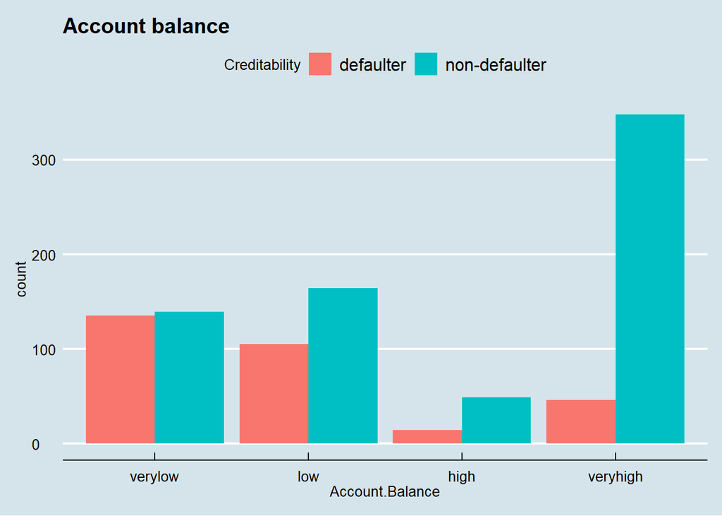

```r
german %>% ggplot(aes(Account.Balance, fill=Creditability))+
  geom_bar(position = "dodge")+
  ggtitle("Account balance ")
```

From the credit amount graph, most people tend to go for less credit there being a higher difference a larger percentage of non defaulters took the less credit amount.

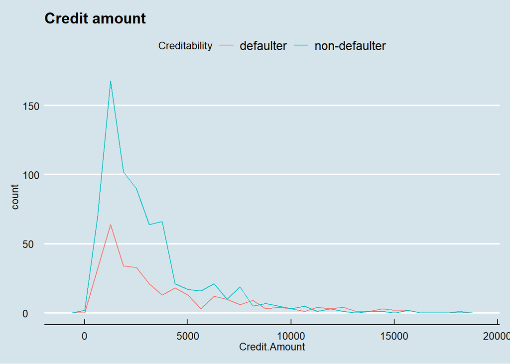

```r
german %>% ggplot(aes(Credit.Amount, col=Creditability))+
  geom_freqpoly()+
  ggtitle("Credit amount")
```

From a general perspective of value savings stock, most are non defaulters. But persons with a very high savings stock tend to be the most defaulters as well as non defaulters.

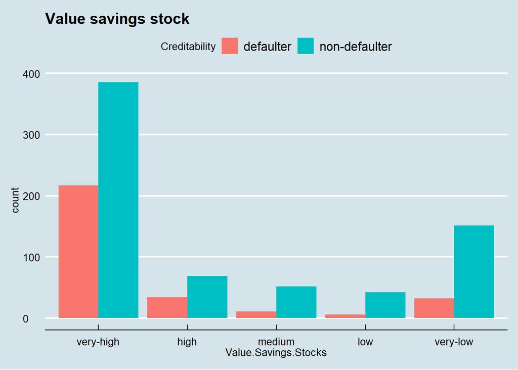

```r
german %>% ggplot(aes(Value.Savings.Stocks, fill=Creditability))+
  geom_bar(position = "dodge")+
  ggtitle("Value savings stock")
```

Business owners hav a higher percentage of taking credit with various reasons like to increase capital investment and as well they most are none defaulters with a close range from land owners.

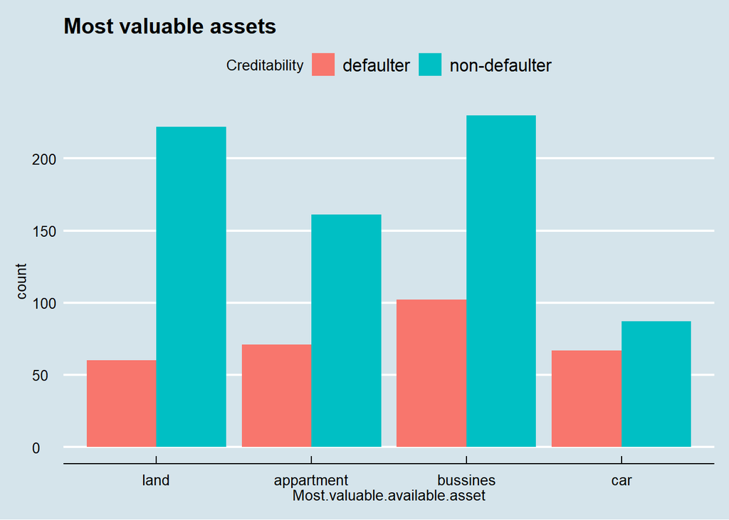

```r
german %>% ggplot(aes(Most.valuable.available.asset, fill=Creditability))+
  geom_bar(position = "dodge")+
  ggtitle("Most valuable assets")
```

Averagely, persons less than 40 years seek more creditwith a lesser percentage being defaulters.

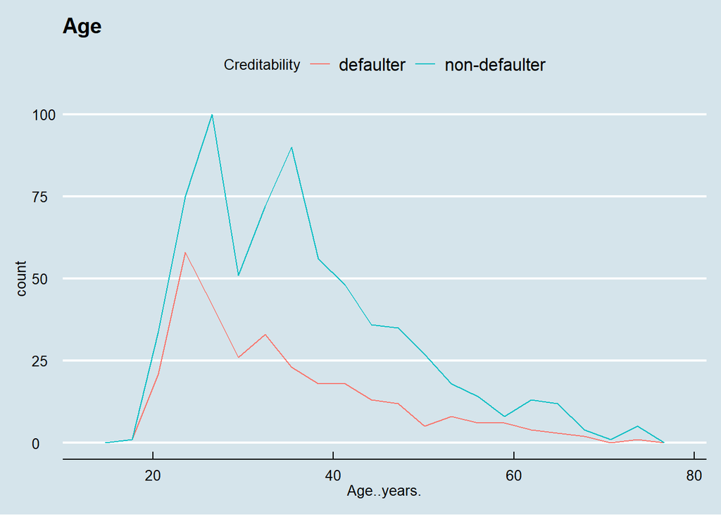

```r
german %>% ggplot(aes(Age..years., col=Creditability))+
  geom_freqpoly(bins=20)+
  ggtitle("Age")
```

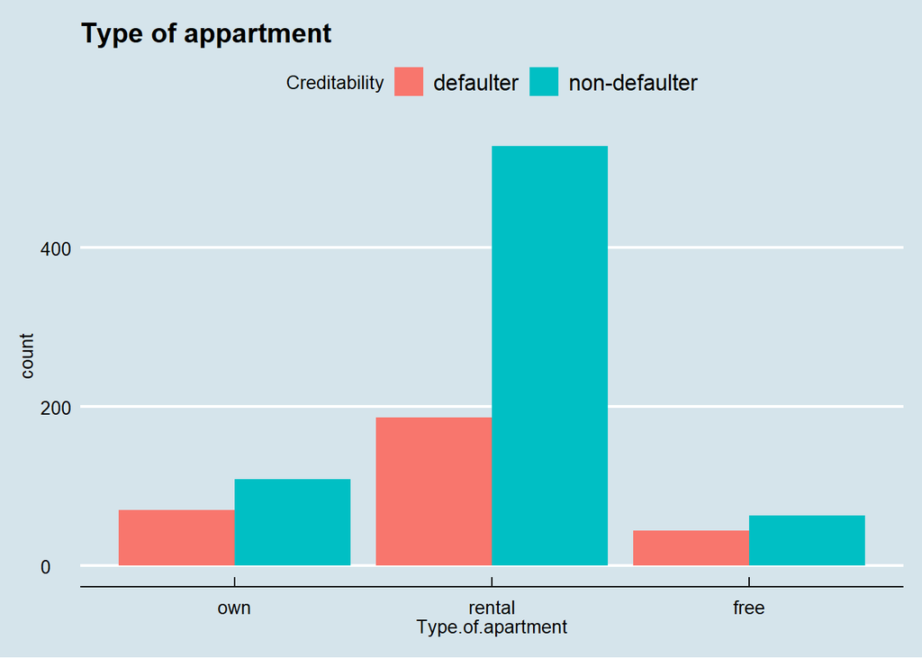

```r
german %>% ggplot(aes(Type.of.apartment, fill=Creditability))+
  geom_bar(position = "dodge")+
  ggtitle("Type of appartment")
```

Persons with fewer dependents seek more credit which from basic assumption it should be vice versa but all in all they have a higher probablity of not defaulting even though the difference is almost lke half of those defaulting.

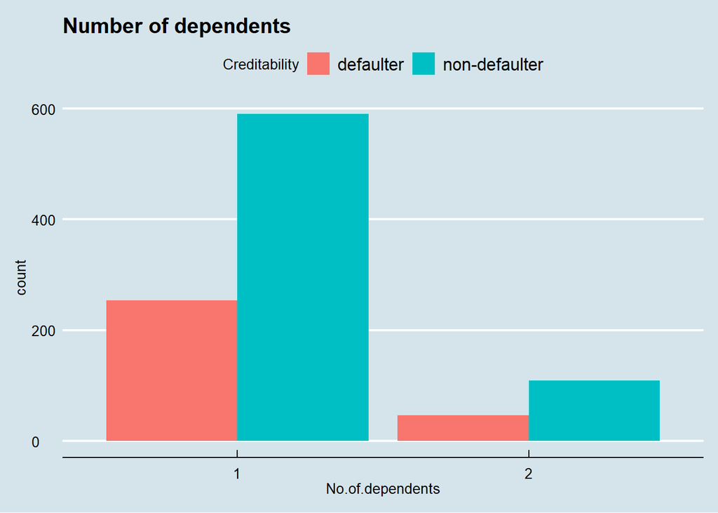

```r
german %>% ggplot(aes(No.of.dependents, fill=Creditability))+
  geom_bar(position = "dodge")+
  ggtitle("Number of dependents")
```

Checking the number of credits at the bank to determine the credibility of the borrower from diverse credit banks.

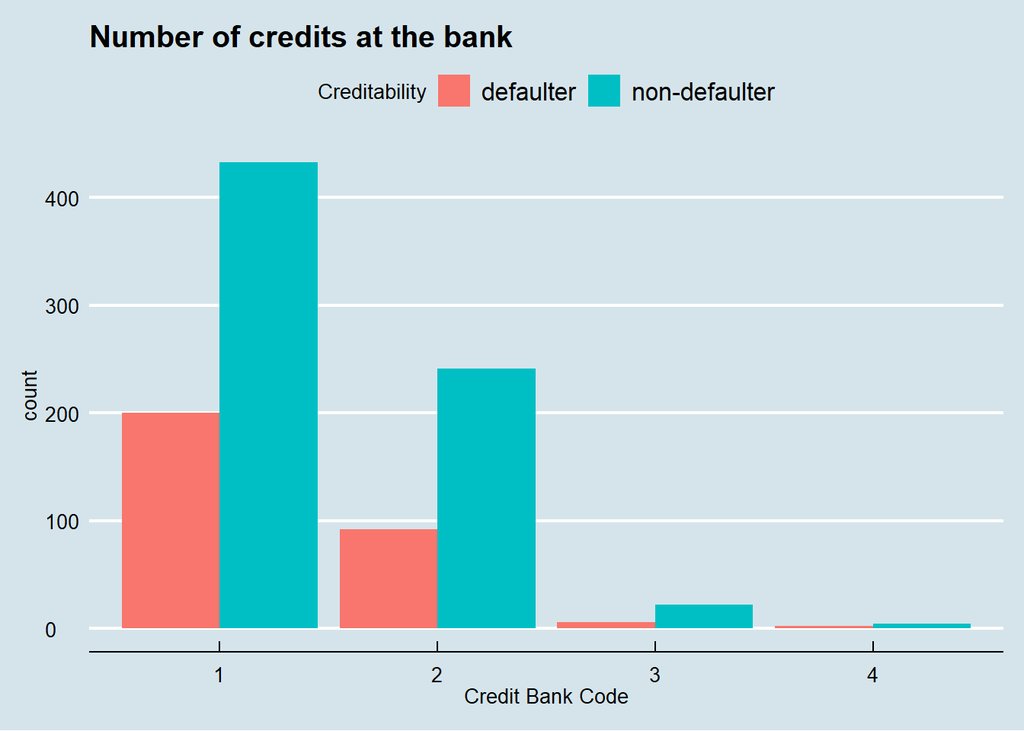

```r
german %>% ggplot(aes(No.of.Credits.at.this.Bank, fill=Creditability))+
  geom_bar(position = "dodge")+
  ggtitle("Number of credits at the bank")+
  xlab("Credit Bank Code")
```

## Next step is to build a Logistic Model and check model summary

```r
mod1=glm(Creditability~., data = train, family = "binomial")
summary(mod1)
```

```
##
## Call:
## glm(formula = Creditability ~ ., family = "binomial", data = train)
##
## Deviance Residuals:
##     Min       1Q   Median       3Q      Max
## -3.0299  -0.6576   0.3134   0.6911   2.7550
##
## Coefficients: (1 not defined because of singularities)
##                                           Estimate Std. Error z value
## (Intercept)                              1.446e+01  1.448e+03   0.010
## Account.Balancelow                       8.589e-01  3.609e-01   2.380
## Account.Balancehigh                      1.618e+00  7.670e-01   2.110
## Account.Balanceveryhigh                  2.647e+00  9.675e-01   2.735
## Duration.of.Credit..month.6             -1.322e+01  1.448e+03  -0.009
## Duration.of.Credit..month.7              4.787e-01  2.216e+03   0.000
## Duration.of.Credit..month.8             -1.416e+01  1.448e+03  -0.010
## Duration.of.Credit..month.9             -1.466e+01  1.448e+03  -0.010
## Duration.of.Credit..month.10            -1.367e+01  1.448e+03  -0.009
## Duration.of.Credit..month.11             2.284e+00  1.880e+03   0.001
## Duration.of.Credit..month.12            -1.425e+01  1.448e+03  -0.010
## Duration.of.Credit..month.13             1.986e+00  2.328e+03   0.001
## Duration.of.Credit..month.14            -1.342e+01  1.448e+03  -0.009
## Duration.of.Credit..month.15            -1.334e+01  1.448e+03  -0.009
## Duration.of.Credit..month.16            -1.737e+01  1.448e+03  -0.012
## Duration.of.Credit..month.18            -1.476e+01  1.448e+03  -0.010
## Duration.of.Credit..month.20            -1.335e+01  1.448e+03  -0.009
## Duration.of.Credit..month.21            -1.409e+01  1.448e+03  -0.010
## Duration.of.Credit..month.22             1.261e+00  3.047e+03   0.000
## Duration.of.Credit..month.24            -1.433e+01  1.448e+03  -0.010
## Duration.of.Credit..month.26             2.698e+00  4.213e+03   0.001
## Duration.of.Credit..month.27            -1.469e+01  1.448e+03  -0.010
## Duration.of.Credit..month.28             1.389e+00  3.122e+03   0.000
## Duration.of.Credit..month.30            -1.458e+01  1.448e+03  -0.010
## Duration.of.Credit..month.33            -1.519e+01  1.448e+03  -0.010
## Duration.of.Credit..month.36            -1.464e+01  1.448e+03  -0.010
## Duration.of.Credit..month.39            -1.375e+01  1.448e+03  -0.009
## Duration.of.Credit..month.40            -3.090e+01  4.213e+03  -0.007
## Duration.of.Credit..month.42            -1.342e+01  1.448e+03  -0.009
## Duration.of.Credit..month.45            -1.687e+01  1.448e+03  -0.012
```

[output cut: 140 more lines]

```
## No.of.dependents2                        0.75459
## Telephone2                               0.13777
## Foreign.Worker2                          0.04724 *
## probability                              0.43247
## prob                                          NA
## ---
## Signif. codes:  0 '***' 0.001 '**' 0.01 '*' 0.05 '.' 0.1 ' ' 1
##
## (Dispersion parameter for binomial family taken to be 1)
##
##     Null deviance: 1101.25  on 899  degrees of freedom
## Residual deviance:  762.61  on 814  degrees of freedom
## AIC: 934.61
##
## Number of Fisher Scoring iterations: 16
```

Since of the variables are not significant,indicated by lack of at least a single star on their coefficient tables, we will rebuild the logistic regression with only the significant variables.

```r
mod2=glm(Creditability~Account.Balance+Payment.Status.of.Previous.Credit+Purpose+Credit.Amount+Value.Savings.Stocks+Instalment.per.cent+Sex...Marital.Status+Guarantors+No.of.Credits.at.this.Bank+Foreign.Worker, family = "binomial", train)
summary(mod2)
```

```
##
## Call:
## glm(formula = Creditability ~ Account.Balance + Payment.Status.of.Previous.Credit +
##     Purpose + Credit.Amount + Value.Savings.Stocks + Instalment.per.cent +
##     Sex...Marital.Status + Guarantors + No.of.Credits.at.this.Bank +
##     Foreign.Worker, family = "binomial", data = train)
##
## Deviance Residuals:
##     Min       1Q   Median       3Q      Max
## -2.6213  -0.7566   0.4315   0.7071   2.4563
##
## Coefficients:
##                                      Estimate Std. Error z value Pr(>|z|)
## (Intercept)                        -6.643e-01  6.901e-01  -0.963 0.335681
## Account.Balancelow                  4.218e-01  2.207e-01   1.911 0.056001
## Account.Balancehigh                 1.155e+00  3.805e-01   3.034 0.002410
## Account.Balanceveryhigh             1.785e+00  2.339e-01   7.631 2.32e-14
## Payment.Status.of.Previous.Credit1 -4.080e-02  5.933e-01  -0.069 0.945166
## Payment.Status.of.Previous.Credit2  9.869e-01  4.949e-01   1.994 0.046117
## Payment.Status.of.Previous.Credit3  1.208e+00  5.303e-01   2.277 0.022775
## Payment.Status.of.Previous.Credit4  1.980e+00  5.011e-01   3.952 7.75e-05
## Purpose1                            1.605e+00  3.833e-01   4.186 2.84e-05
## Purpose2                            5.760e-01  2.560e-01   2.250 0.024431
## Purpose3                            8.682e-01  2.500e-01   3.473 0.000516
## Purpose4                            4.959e-01  7.223e-01   0.687 0.492363
## Purpose5                            2.394e-01  5.385e-01   0.445 0.656596
## Purpose6                           -2.988e-01  3.952e-01  -0.756 0.449503
## Purpose8                            2.197e+00  1.171e+00   1.876 0.060633
## Purpose9                            3.936e-01  3.317e-01   1.186 0.235466
## Purpose10                           1.445e+00  7.964e-01   1.814 0.069605
## Credit.Amount                      -1.978e-04  3.577e-05  -5.528 3.24e-08
## Value.Savings.Stockshigh            9.242e-02  2.830e-01   0.327 0.743997
## Value.Savings.Stocksmedium          1.384e-01  4.025e-01   0.344 0.730924
## Value.Savings.Stockslow             1.106e+00  5.033e-01   2.197 0.028027
## Value.Savings.Stocksvery-low        6.641e-01  2.662e-01   2.495 0.012602
## Instalment.per.cent2               -2.389e-01  3.131e-01  -0.763 0.445348
## Instalment.per.cent3               -7.013e-01  3.356e-01  -2.090 0.036639
## Instalment.per.cent4               -1.074e+00  2.933e-01  -3.662 0.000250
## Sex...Marital.Statusfemale-married  9.570e-04  3.837e-01   0.002 0.998010
## Sex...Marital.Statusmale-single     7.166e-01  3.789e-01   1.891 0.058617
```

[output cut: 37 more lines]

```
## Guarantors3                        .
## No.of.Credits.at.this.Bank2        *
## No.of.Credits.at.this.Bank3
## No.of.Credits.at.this.Bank4
## Foreign.Worker2                    *
## ---
## Signif. codes:  0 '***' 0.001 '**' 0.01 '*' 0.05 '.' 0.1 ' ' 1
##
## (Dispersion parameter for binomial family taken to be 1)
##
##     Null deviance: 1101.25  on 899  degrees of freedom
## Residual deviance:  843.43  on 866  degrees of freedom
## AIC: 911.43
##
## Number of Fisher Scoring iterations: 5
```

Sex..marital.status poses as an insignificant variable in the second model. We build a third logistic model with only significant variables.

**Revised logistic regression model.**

```r
mod3=glm(Creditability~Account.Balance+Payment.Status.of.Previous.Credit+Purpose+Credit.Amount+Value.Savings.Stocks+Instalment.per.cent+No.of.Credits.at.this.Bank+Foreign.Worker, train, family = "binomial")
summary(mod3)
```

```
##
## Call:
## glm(formula = Creditability ~ Account.Balance + Payment.Status.of.Previous.Credit +
##     Purpose + Credit.Amount + Value.Savings.Stocks + Instalment.per.cent +
##     No.of.Credits.at.this.Bank + Foreign.Worker, family = "binomial",
##     data = train)
##
## Deviance Residuals:
##     Min       1Q   Median       3Q      Max
## -2.7649  -0.7765   0.4400   0.7426   2.2427
##
## Coefficients:
##                                      Estimate Std. Error z value Pr(>|z|)
## (Intercept)                        -4.701e-01  5.841e-01  -0.805 0.420839
## Account.Balancelow                  4.420e-01  2.156e-01   2.050 0.040317
## Account.Balancehigh                 1.127e+00  3.747e-01   3.009 0.002624
## Account.Balanceveryhigh             1.779e+00  2.318e-01   7.673 1.68e-14
## Payment.Status.of.Previous.Credit1  3.091e-03  5.796e-01   0.005 0.995744
## Payment.Status.of.Previous.Credit2  9.449e-01  4.827e-01   1.958 0.050280
## Payment.Status.of.Previous.Credit3  1.260e+00  5.225e-01   2.412 0.015884
## Payment.Status.of.Previous.Credit4  1.939e+00  4.902e-01   3.955 7.64e-05
## Purpose1                            1.647e+00  3.744e-01   4.399 1.09e-05
## Purpose2                            5.147e-01  2.523e-01   2.040 0.041386
## Purpose3                            8.781e-01  2.433e-01   3.609 0.000308
## Purpose4                            3.684e-01  7.011e-01   0.525 0.599282
## Purpose5                            2.543e-01  5.391e-01   0.472 0.637182
## Purpose6                           -3.006e-01  3.891e-01  -0.772 0.439832
## Purpose8                            2.042e+00  1.149e+00   1.777 0.075521
## Purpose9                            4.139e-01  3.272e-01   1.265 0.205814
## Purpose10                           1.319e+00  7.265e-01   1.816 0.069433
## Credit.Amount                      -1.829e-04  3.429e-05  -5.333 9.66e-08
## Value.Savings.Stockshigh            3.706e-02  2.811e-01   0.132 0.895120
## Value.Savings.Stocksmedium          1.757e-01  3.993e-01   0.440 0.659964
## Value.Savings.Stockslow             9.773e-01  4.986e-01   1.960 0.049978
## Value.Savings.Stocksvery-low        6.852e-01  2.607e-01   2.628 0.008579
## Instalment.per.cent2               -1.140e-01  3.057e-01  -0.373 0.709132
## Instalment.per.cent3               -5.312e-01  3.262e-01  -1.628 0.103460
## Instalment.per.cent4               -8.652e-01  2.811e-01  -3.078 0.002085
## No.of.Credits.at.this.Bank2        -4.537e-01  2.415e-01  -1.878 0.060318
## No.of.Credits.at.this.Bank3        -2.281e-01  5.604e-01  -0.407 0.683989
```

[output cut: 27 more lines]

```
## Instalment.per.cent4               **
## No.of.Credits.at.this.Bank2        .
## No.of.Credits.at.this.Bank3
## No.of.Credits.at.this.Bank4
## Foreign.Worker2                    *
## ---
## Signif. codes:  0 '***' 0.001 '**' 0.01 '*' 0.05 '.' 0.1 ' ' 1
##
## (Dispersion parameter for binomial family taken to be 1)
##
##     Null deviance: 1101.25  on 899  degrees of freedom
## Residual deviance:  863.74  on 871  degrees of freedom
## AIC: 921.74
##
## Number of Fisher Scoring iterations: 5
```

**Using the revised model to make predictions on the test data.**

We will store the predictions in a vector ‘prob’ then create a factor variable ‘Prediction’ from the probabilities and add it to the test dataset.

```r
prob=predict(mod3, newdata = test, type = "response")
train$prob=predict(mod3, newdata = train, type = "response")
test$Prediction=ifelse(prob>=0.5, "NON-DEFAULTER", "DEFAULTER")
```

##Predicting and assesing the model. To do this we perfom a quick evaluation on the training set by plotting the probability (score) estimated by our model.

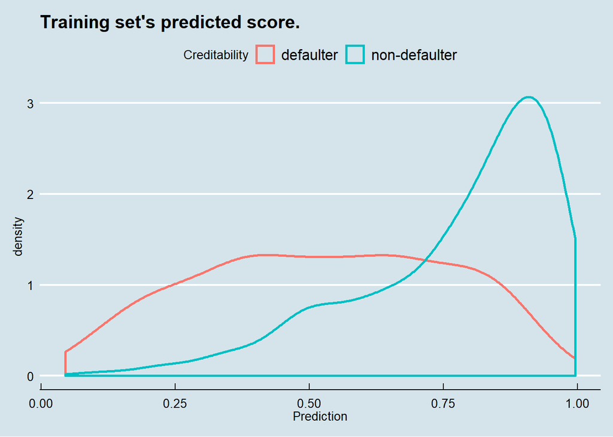

```r
train %>% ggplot(aes(prob, color=Creditability)) +
  geom_density(size=1)+
  theme_economist()+
  ggtitle("Training set's predicted score.")+
  xlab("Prediction")
```

Majority of our score is pulled towards the upper since most of our data given has many NON-DEFAULTERS.

**Measure the accuracy of the model.**

```r
table(test$Creditability, test$Prediction)
```

```
##
##                 DEFAULTER NON-DEFAULTER
##   defaulter            13            16
##   non-defaulter         9            62
```

**Compute the accuracy of the logit model.**

```r
(13+62)/nrow(test)
```

```
## [1] 0.75
```

The accuracy is 0.75.

**computing sensitivity**

```r
62/(9+62)
```

```
## [1] 0.8732394
```

The sensitivity is 0.87

**Computing specificity**

```r
13/(13+16)
```

```
## [1] 0.4482759
```

specificity is 0.45

We infer that the model is doing far much better in sensitivity as compared to specificity. Next we compare model’s accuracy to the baseline accuracy.

Comparing baseline accuracy

```r
table(test$Creditability)
```

```
##
##     defaulter non-defaulter
##            29            71
```

```r
29/(29+71)
```

```
## [1] 0.29
```

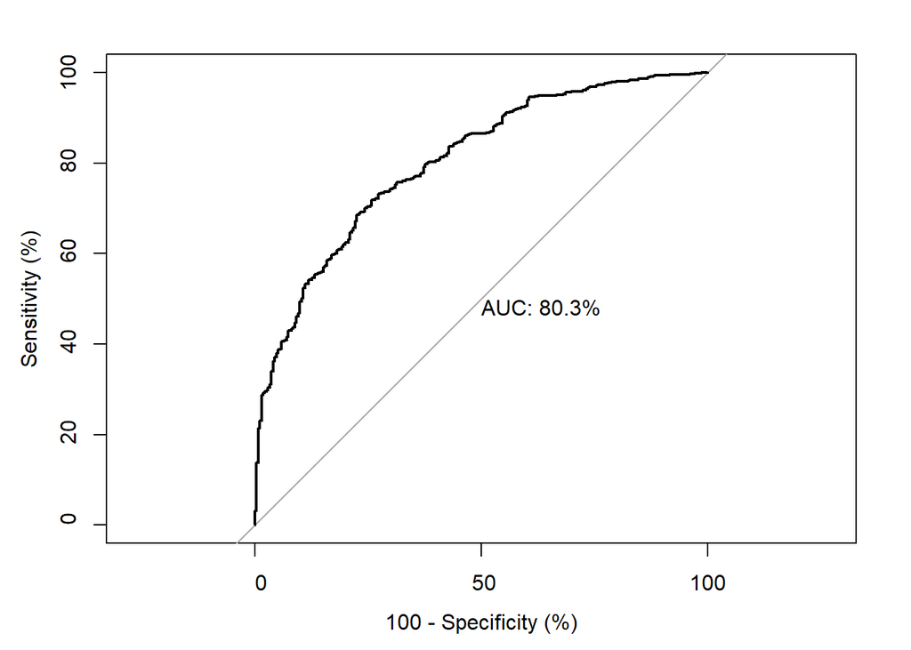

```
##
## Call:
## roc.default(response = train$Creditability, predictor = mod3$fitted.values,     percent = TRUE, plot = TRUE, legacy.axes = TRUE, print.auc = TRUE)
##
## Data: mod3$fitted.values in 271 controls (train$Creditability defaulter) < 629 cases (train$Creditability non-defaulter).
## Area under the curve: 80.26%
```

```r
roc(train$Creditability, mod3$fitted.values, plot = TRUE, legacy.axes= TRUE, percent = TRUE,
    print.auc = TRUE)
```

The second part tells us how many samples were defaulters(271) and non-defaulters(629). And lastly the Area Under Curve **AUC** which amounts to 80%